# Class 15: Fundamentals of Data Visualization

Trey Patrick

2026-10-14

> Phase II starts here (Data Visualization & Communication, Oct 14 to Exam 02 on Nov 16). There was no R in class today; these are my notes from the slides, plus a few small chunks that reproduce the examples. Monday (Oct 19) turns these principles into ggplot2 code.

**Learning objectives:** (1) explain Tufte’s principles of graphical excellence, (2) select visual encodings based on data types, (3) apply color theory and accessibility guidelines, (4) identify and critique misleading visualizations.

# 1 Part 1: Graphical Excellence

## 1.1 Terrible charts (opening activity)

- **Russia vs Ukraine defense budgets (two squares):** the values are encoded by **area**, and we judge area poorly. A 14× bigger budget doesn’t look 14× bigger.
- **White House economic-growth bar chart:** the highlighted bar and the non-zero / inconsistent scale exaggerate the difference (it was later corrected).
- **Fox News share of Christians, 2009 vs 2019:** the y-axis doesn’t start at zero, so the bar heights exaggerate the change.

## 1.2 What should graphs do? (Tufte, 2001, p. 13)

1. **Show the data.**
2. Lead the viewer to think about the **substance**, not the design.
3. **Avoid distorting** what the data have to say.
4. Present **many numbers in a small space**.
5. Make **large datasets coherent**.
6. **Encourage the eye to compare** (put values on a common scale).
7. Reveal the data at **several levels of detail** (overview + fine structure).
8. Serve a **clear purpose**: description, exploration, tabulation, or decoration.
9. Be **closely integrated** with the statistical and verbal descriptions (titles and labels say what the graph shows).

## 1.3 Show the data: Anscombe’s quartet

Anscombe (1973): “a computer should **make both calculations and graphs**.” Four datasets with the same summaries, but completely different pictures.

```r
quartet = datasets::anscombe |>
  tidyr::pivot_longer(dplyr::everything(),
                      names_to = c(".value", "set"),
                      names_pattern = "(.)(.)") |>    # x1 -> x + set 1, y1 -> y + set 1
  dplyr::mutate(set = paste("Set", set))

# same means, SDs, and correlation (to 2 decimals) in every set
quartet |>
  dplyr::group_by(set) |>
  dplyr::summarise(mean_x = mean(x), sd_x = sd(x),
                   mean_y = mean(y), sd_y = sd(y),
                   correlation = cor(x, y)) |>
  dplyr::mutate(dplyr::across(-set, \(v) round(v, 2)))
```

```
## # A tibble: 4 x 6
##   set   mean_x  sd_x mean_y  sd_y correlation
##   <chr>  <dbl> <dbl>  <dbl> <dbl>       <dbl>
## 1 Set 1      9  3.32    7.5  2.03        0.82
## 2 Set 2      9  3.32    7.5  2.03        0.82
## 3 Set 3      9  3.32    7.5  2.03        0.82
## 4 Set 4      9  3.32    7.5  2.03        0.82
```

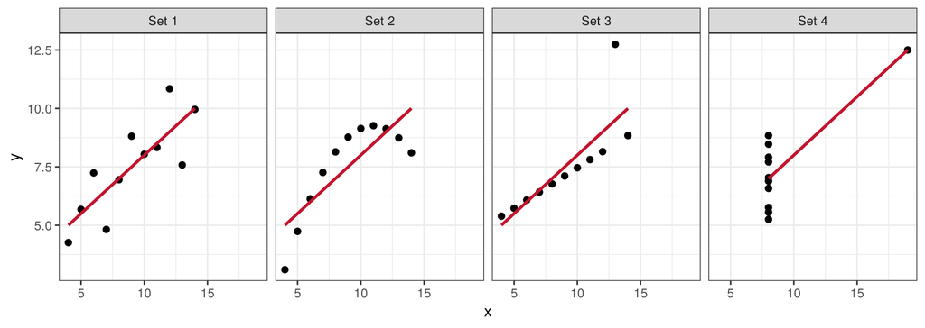

```r
ggplot2::ggplot(quartet, ggplot2::aes(x, y)) +
  ggplot2::geom_point(size = 1.8) +
  ggplot2::geom_smooth(method = lm, se = FALSE, formula = y ~ x, color = "#C3142D") +
  ggplot2::facet_wrap(~set, nrow = 1) +
  ggplot2::theme_bw()
```

Set 1 is a noisy line, Set 2 is a curve, Set 3 is a line with one outlier, and in Set 4 one point sets the slope. The fitted line is the same in all four. The **Datasaurus** (Matejka & Fitzmaurice, 2017) does the same thing with a dinosaur.

## 1.4 Substance: Playfair’s cities

Bubble chart of 22 European cities → hard to rank because we compare **areas**. Better: a **dot chart**, where population is a **position** on one common axis.

```r
# needs internet; the data are Playfair's populations (thousands) from the late 1700s
playfair = read.table("http://www.stat.uiowa.edu/~luke/data/Playfair") |>
  tibble::rownames_to_column(var = "city") |>
  tibble::as_tibble() |>
  dplyr::arrange(dplyr::desc(population))

playfair |>
  ggplot2::ggplot(ggplot2::aes(x = population, y = stats::reorder(city, population))) +
  ggplot2::geom_point() +
  ggplot2::scale_x_continuous(labels = scales::comma) +
  ggplot2::labs(x = "Population (thousands)", y = "City") +
  ggplot2::theme_bw()
```

## 1.5 Avoid distortion: the lie factor

$$\text{Lie factor} = \frac{\text{size of
effect shown in the graphic}}{\text{size of effect in the
data}}$$

Both “effects” are percent changes: (new − old) / old. Tufte’s fuel-economy chart:

```r
data_change    = (27.5 - 18) / 18     # 18 mpg (1978) -> 27.5 mpg (1985): +53%
graphic_change = (5.3 - 0.6) / 0.6    # line 0.6 in -> 5.3 in: +783%
lie_factor = graphic_change / data_change
round(c(data_change = data_change, graphic_change = graphic_change, lie_factor = lie_factor), 2)
```

```
##    data_change graphic_change     lie_factor
##           0.53           7.83          14.84
```

- **Lie factor = 1** means the graphic is honest. Tufte treats **> 1.05 or < 0.95** as substantial distortion. This chart exaggerates the change about **15×**.
- Other distortion examples: Tufte’s bar chart with a non-zero baseline and pictures; Fox Business’s top-tax-rate chart with the **y-axis starting at 34%**.
- **Summary:** label clearly, keep the lie factor near 1, and make variation come from the **data**, not the design.

# 2 Part 2: Data-Ink and Chartjunk

- **Data-ink** = the non-erasable ink that shows the data.
- **Data-ink ratio** = data-ink / total ink = **1 − (share of the graphic you could erase without losing data)**. Ask: *what could I erase without losing any data?*
- **Chartjunk** = extraneous visual elements that distract from the message (heavy gridlines, 3-D, backgrounds, decoration). Tim Bray’s 6-step example strips it away one piece at a time.
- **But it’s a guideline, not a law.** Hanrahan: aesthetics, style, playfulness and vividness have value. **Bateman et al. (2010):** embellished charts were described no less accurately and **remembered better** 2–3 weeks later. **Distortion is never OK; decoration is a judgment call.**

# 3 Part 3: Data Types and Visual Encoding

## 3.1 Stevens (1946): scales of measurement

| Type | Meaning | Example |
| --- | --- | --- |
| **Nominal** | values are = or ≠ (labels) | apples, bananas, oranges |
| **Ordinal** | values have an order (<) | small, medium, large |
| **Interval** (quantitative) | differences mean something; **zero is arbitrary** | dates, latitude/longitude, °F |
| **Ratio** (quantitative) | **zero is fixed**, so ratios mean something | length, weight, cost, counts |

**Test:** does “twice as much” make sense? $40 vs $20 → yes, so it’s **ratio**. 40°F vs 20°F → no, so it’s **interval**.

**Why it matters:** a bar’s length shows a value as a distance from zero, which works for **ratio** data. For **interval** data, use positions (dots, lines) instead of bars.

## 3.2 In-class activity: shipping data

| Column | Type | Why |
| --- | --- | --- |
| Order ID | Nominal | a label; averaging IDs means nothing |
| Order Date / Ship Date | Interval | the difference (days to ship) means something; a ratio of dates doesn’t |
| Order Priority | Ordinal | urgent > high > medium > low, but the gaps aren’t equal |
| Product Container | Nominal | box sizes look ordered, but “wrap bag” has no place in that order |
| Product Cost | Ratio | $0 = no cost, so $40 is twice $20 |

The type comes from **what the values mean**, not how they’re stored. The same column (e.g., temperature) can be quantitative, ordinal (hot/warm/cold) or nominal (burned / not burned), depending on the question.

## 3.3 Visual variables and precision

- **Bertin (1967)** visual variables: position, size, shape, value (lightness), color hue, orientation, texture.
- **Matching variables to data types:** position works for everything; hue and shape suit **nominal** data; lightness and size suit **ordinal** and **quantitative** data.
- **Precision ranking (Franconeri et al., 2021):** **position** (most precise) > **length** > **area / angle** > **color intensity** (least precise).
- That’s why Russia’s squares and Playfair’s bubbles (area) lose to a dot chart (position).

# 4 Part 4: Color, Used Sparingly

- **Simultaneous contrast:** the same gray looks lighter or darker depending on what surrounds it.
- **Color vision deficiency:** “About 1 in 12 men have color vision deficiency” (National Eye Institute). Deuteranopia (reduced green sensitivity) is the most common type. **Red/green palettes collapse** for those readers. The **Okabe-Ito** palette keeps groups apart.
- **Fix:** use color sparingly and choose colorblind-safe palettes (colorbrewer2.org with “colorblind safe” checked).
- **ColorBrewer scale types:**
  - **Sequential:** ordered values, low → high
  - **Diverging:** there’s a meaningful midpoint (e.g., above / below average)
  - **Qualitative:** nominal categories

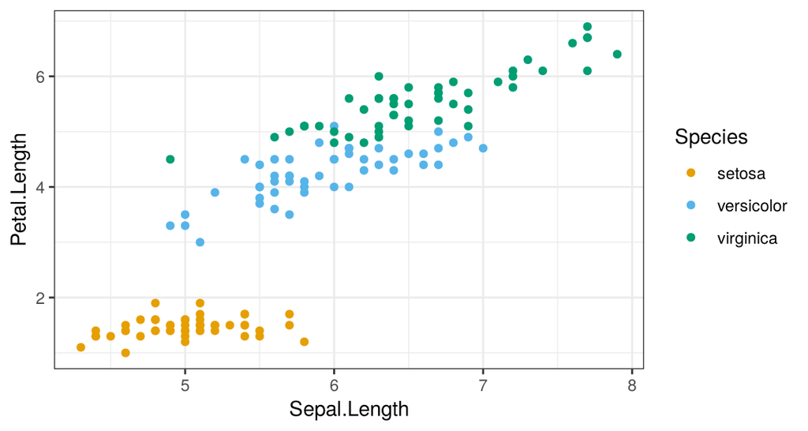

```r
okabe_ito = c("#E69F00", "#56B4E9", "#009E73")   # colorblind-safe
ggplot2::ggplot(datasets::iris, ggplot2::aes(Sepal.Length, Petal.Length, color = Species)) +
  ggplot2::geom_point() +
  ggplot2::scale_color_manual(values = okabe_ito) +
  ggplot2::theme_bw()
```

# 5 Summary

- Show the data, keep the focus on substance, avoid distortion (Anscombe, Playfair, lie factor, data-ink ratio).
- Choose encodings from the data type (nominal, ordinal, interval, ratio). **Position** is perceived most accurately.
- Use color sparingly; match sequential / diverging / qualitative scales to the data; design for color-blind readers.
- Critique misleading charts: non-zero baselines, area encodings, a lie factor far from 1.

**Reading before Monday:** de Boer (2021), *The Lie Factor and the Baseline Paradox* (Nightingale). Wilke, *Fundamentals of Data Visualization*, ch. 4 (color scales) and ch. 19 (pitfalls of color use). Skim if curious: Bateman et al. (2010), *Useful junk?*